# **Milestone 2**

by Sulian Thual - for MIT ASDP October 2021

We build a computer vision model for malaria detection. In this notebook we work on Milestone 2, which consists in building the model and experimenting on its characteristics (architecture, hyperparameters, etc) for improved performances.

Note: for best performances, use Google Collab. Select Edit/Notebook Settings/GPU.

# **Part I: Base Functions**

### **Mounting the Drive**

```python
#Mounting the drive
from google.colab import drive
drive.mount('/content/drive')
```

### **Loading libraries**

```python
#Importing libraries required to load the data

import zipfile
import os
from PIL import Image
import numpy as np
import pandas as pd
import matplotlib.pyplot as plt
import seaborn as sns
import cv2
import gc

from sklearn.model_selection import train_test_split
from sklearn.preprocessing import MinMaxScaler

import tensorflow as tf
from tensorflow.keras.models import Sequential
from tensorflow.keras.layers import Dense, Conv2D, MaxPool2D, BatchNormalization, Dropout, Flatten, LeakyReLU, GlobalAvgPool2D
from tensorflow.keras.utils import to_categorical
from tensorflow.keras import optimizers


#to ignore warnings
import warnings
warnings.filterwarnings('ignore')

# Remove the limit from the number of displayed columns and rows. It helps to see the entire dataframe while printing it
pd.set_option("display.max_columns", None)
pd.set_option("display.max_rows", 200)
```

### **Let us load the data**

**Note:**

- You must download the dataset from the link provided on Olympus and upload the same on your Google drive before executing the code in the next cell.
- In case of any error, please make sure that the path of the file is correct as the path may be different for you.

```python
#Storing the path of the data file from the Google drive
path = '/content/drive/MyDrive/Data/cell_images.zip'

#The data is provided as a zip file so we need to extract the files from the zip file
with zipfile.ZipFile(path, 'r') as zip_ref:
    zip_ref.extractall()
```

The files have been extracted to the local session of Google Colab. The extracted folder would have the following structure:

The extracted folder has different folders for train and test data which further contains the different sizes of images for parasitized and uninfected cells within the respective folder name.

The size of all images must be the same and should be converted to 4D arrays so that they can be used as an input for the convolutional neural network. Also, we need to create the labels for both types of images to be able to train and test the model.

Let's do the same for the training data first and then we will use the same code for the test data as well.

```python
#Storing the path of the extracted "train" folder
train_dir = '/content/cell_images/train'

#Size of image so that each image has the same size
SIZE = 64

#Empty list to store the training images after they are converted to NumPy arrays
train_images = []
train_bigimages= []

#Empty list to store the training labels (0 - uninfected, 1 - parasitized)
train_labels = []
```

```python
#We will run the same code for "parasitized" as well as "uninfected" folders within the "train" folder
for folder_name in ['/parasitized/', '/uninfected/']:

    #Path of the folder
    images_path = os.listdir(train_dir + folder_name)

    for i, image_name in enumerate(images_path):
        try:
            #Opening each image using the path of that image
            image = Image.open(train_dir + folder_name + image_name)

            #Resizing each image to (224,224)
            bigimage = image.copy()
            image = image.resize((SIZE, SIZE))

            #Converting images to arrays and appending that array to the empty list defined above
            train_images.append(np.array(image))
            train_bigimages.append(np.array(bigimage))

            #Creating labels for parasitized and uninfected images
            if folder_name=='/parasitized/':
                train_labels.append(1)
            else:
                train_labels.append(0)
        except Exception:
            pass

#Converting lists to arrays
train_images = np.array(train_images)
train_bigimages = np.array(train_bigimages)
train_labels = np.array(train_labels)
```

```python
#Storing the path of the extracted "test" folder
test_dir = '/content/cell_images/test'

#Size of image so that each image has the same size (it must be same as the train image size)
SIZE = 64

#Empty list to store the testing images after they are converted to NumPy arrays
test_images = []
test_bigimages = []

#Empty list to store the testing labels (0 - uninfected, 1 - parasitized)
test_labels = []
```

```python
#We will run the same code for "parasitized" as well as "uninfected" folders within the "test" folder
for folder_name in ['/parasitized/', '/uninfected/']:

    #Path of the folder
    images_path = os.listdir(test_dir + folder_name)

    for i, image_name in enumerate(images_path):
        try:
            #Opening each image using the path of that image
            image = Image.open(test_dir + folder_name + image_name)

            #Resizing each image to (128,128)
            bigimage = image.copy()
            image = image.resize((SIZE, SIZE))


            #Converting images to arrays and appending that array to the empty list defined above
            test_images.append(np.array(image))
            test_bigimages.append(np.array(bigimage))

            #Creating labels for parasitized and uninfected images
            if folder_name=='/parasitized/':
                test_labels.append(1)
            else:
                test_labels.append(0)
        except Exception:
            pass

#Converting lists to arrays
test_images = np.array(test_images)
test_bigimages = np.array(test_bigimages)
test_labels = np.array(test_labels)
```

### **Normalize the images**

```python
# try to normalize the train and test images by dividing it by 255 and convert them to float32 using astype function
for i in train_images:
  i=(i/255).astype('float32')
for i in test_images:
  i=(i/255).astype('float32')
# for i in train_bigimages:
  # i=(i/255).astype('float32')
# for i in test_bigimages:
  # i=(i/255).astype('float32')
# train_images = (i/255).astype('float32')
# test_images = (test_images/255).astype('float32')
# train_bigimages = (train_bigimages/255).astype('float32')
# test_bigimages = (test_bigimages/255).astype('float32')
```

As we have done our preprocessing required and performed some EDA to gain some insights in our Milestone-1 so now we will try to build our model and try evaluating its performance.

### **One Hot Encoding on the train and test labels**

```python
# Encoding Train Labels
train_labels=to_categorical(train_labels,2)
# Similarly let us try to encode test labels
test_labels=to_categorical(test_labels,2)
```

#### **Importing the required libraries**

```python
#Clearing backend
from tensorflow.keras import backend
from tensorflow.keras.utils import to_categorical
from tensorflow.keras.models import Sequential
from tensorflow.keras.layers import Conv2D,MaxPooling2D,Dense,Flatten,Dropout
from tensorflow.keras.callbacks import EarlyStopping, ModelCheckpoint
from random import shuffle

backend.clear_session()
#Fixing the seed for random number generators so that we can ensure we receive the same output everytime
np.random.seed(42)
import random
random.seed(42)
tf.random.set_seed(42)
```

#### **Other functions**

```python
from sklearn.metrics import classification_report
from sklearn.metrics import confusion_matrix

# I modified this into a function for brievety
def prediction_report(model,test_dataset):
  pred = model.predict(test_dataset)
  pred = np.argmax(pred,axis = -1)
  y_true = np.argmax(test_labels,axis = -1)

  #Printing the classification report
  print(classification_report(y_true,pred))

  #Plotting the heatmap using confusion matrix
  cm = confusion_matrix(y_true,pred)
  plt.figure(figsize=(8,5))
  sns.heatmap(cm, annot=True,  fmt='.0f', xticklabels=['Uninfected', 'Parasitized'], yticklabels=['Uninfected', 'Parasitized'])
  plt.ylabel('Actual')
  plt.xlabel('Predicted')
  plt.show()

# function to plot train and validation accuracy
def plot_accuracy(history):
    N = len(history.history["accuracy"])
    plt.figure(figsize=(7,7))
    plt.plot(np.arange(0, N), history.history["accuracy"], label="train_accuracy", ls='--')
    plt.plot(np.arange(0, N), history.history["val_accuracy"], label="val_accuracy", ls='--')
    plt.title("Accuracy vs Epoch")
    plt.xlabel("Epochs")
    plt.ylabel("Accuracy")
    plt.legend(loc="upper left")
```

```python
# Visualize random images (from any database)
def plot_randomimages(image_database,label_database,seed=None):
  if seed:
    np.random.seed(seed)
  else:
    np.random.seed()# renew random each time
  plt.figure(1 , figsize = (18 , 8))
  for n in range(1, 37):
      plt.subplot(4, 9, n)
      index = int(np.random.randint(0, image_database.shape[0], 1))
      label=label_database[index]
      label=np.argmax(label,axis=-1)# convert to 0-1 from potential OHE
      if label == 1: # we assume it is encoded
          plt.title(str(index)+' - 1',color='r')
      else:
          plt.title(str(index)+' - 0')
      plt.imshow(image_database[index])
      plt.axis('off')
```

```python
#Visualize one image
def plot_oneimage(image,label):
  plt.figure(None , figsize = (4 , 4))
  label=np.argmax(label,axis=-1)# convert to 0-1 from potential OHE
  if label == 1: # we assume it is encoded
      plt.title('parasitized')
  else:
      plt.title('uninfected')
  plt.imshow(image)
  plt.axis('off')
```

```python
# color histogram
def plot_colorhist(image):
  plt.figure()
  for i, col in enumerate(['b', 'g', 'r']):
      hist = cv2.calcHist([image], [i], None, [256], [0, 256])
      plt.plot(hist, color = col)
      plt.xlim([0, 256])# omit 0=black borders
  plt.show()
```

```python
def translate_perio(image,dx,dy):# translate image by amount dx>0 and dy>0
  dx +=1
  dy +=1
  new_image=image.copy()
  new_image.fill(255)# just for test
  nx,ny,nc=new_image.shape
  dx=min(dx,nx)
  dy=min(dy,ny)
  dx=max(dx,1)
  dy=max(dy,1)
  new_image[0:dx-1,:,:]=image[nx-dx:nx-1,:,:]# only x
  new_image[dx-1:nx-1,:,:]=image[0:nx-dx,:,:]# only x
  new_image2=new_image.copy()
  new_image2[:,0:dy-1,:]=new_image[:,ny-dy:ny-1,:]# only y
  new_image2[:,dy-1:ny-1,:]=new_image[:,0:ny-dy,:]# only y
  return new_image2
```

```python
import tensorflow as tf
from keras import layers
from keras.layers import Dropout , Input, Add, Dense, Activation, ZeroPadding2D, BatchNormalization, Flatten, Conv2D, AveragePooling2D, MaxPooling2D, GlobalMaxPooling2D
from keras.models import Model, load_model
from keras.initializers import glorot_uniform

def buildCNN5():
  # Model CNN5 buildup
  inp = Input(shape = (64 , 64 , 3))
  x = Conv2D(filters = 16 , kernel_size = (3,3) , strides = (1,1) , padding = "same" , kernel_initializer=glorot_uniform(seed = 2))(inp)
  x = Activation("relu")(x)
  x = Dropout(0.2)(x)
  x = Conv2D(filters = 32 , kernel_size = (4,4) , strides = (2,2) , padding = "same" , kernel_initializer=glorot_uniform(seed = 2))(x)
  x = Activation("relu")(x)
  x = MaxPooling2D(pool_size = (2,2) , strides = (2,2) , padding = "same")(x)
  x = Dropout(0.2)(x)
  x = Conv2D(filters = 64 , kernel_size = (3,3) , strides = (2,2) , padding = "same" , kernel_initializer = glorot_uniform(seed = 2))(x)
  x = Activation("relu")(x)
  x = Dropout(0.2)(x)
  x = Conv2D(filters = 128 , kernel_size = (3,3) , strides = (1,1) , padding = "same" , kernel_initializer = glorot_uniform())(x)
  x = Activation("relu")(x)
  x = MaxPooling2D(pool_size = (2,2) , strides = (2,2) , padding = "same")(x)
  x = Dropout(0.2)(x)
  x = Conv2D(filters = 256 , kernel_size = (2,2) , strides = (2,2) , padding = "same" , kernel_initializer = glorot_uniform())(x)
  x = Activation("relu")(x)
  x = AveragePooling2D(pool_size = (3,3) , strides = (1,1) , padding = "same")(x)
  x = Dropout(0.2)(x)
  x = Flatten()(x)
  x = Dense(128)(x)
  x = Activation("relu")(x)
  x = Dropout(0.2)(x)
  x = Dense(64)(x)
  x = Activation("relu")(x)
  x = Dropout(0.2)(x)
  x = Dense(32)(x)
  x = Activation("relu")(x)
  x = Dropout(0.2)(x)
  x = Dense(2)(x)
  output = Activation("softmax")(x)
  model  = Model(inputs =inp , outputs = output )
  return model
```

```python
model5=buildCNN5()
model5.summary()
```

```
Model: "model_1"
_________________________________________________________________
Layer (type)                 Output Shape              Param #
=================================================================
input_2 (InputLayer)         [(None, 64, 64, 3)]       0
_________________________________________________________________
conv2d_5 (Conv2D)            (None, 64, 64, 16)        448
_________________________________________________________________
activation_9 (Activation)    (None, 64, 64, 16)        0
_________________________________________________________________
dropout_8 (Dropout)          (None, 64, 64, 16)        0
_________________________________________________________________
conv2d_6 (Conv2D)            (None, 32, 32, 32)        8224
_________________________________________________________________
activation_10 (Activation)   (None, 32, 32, 32)        0
_________________________________________________________________
max_pooling2d_2 (MaxPooling2 (None, 16, 16, 32)        0
_________________________________________________________________
dropout_9 (Dropout)          (None, 16, 16, 32)        0
_________________________________________________________________
conv2d_7 (Conv2D)            (None, 8, 8, 64)          18496
_________________________________________________________________
activation_11 (Activation)   (None, 8, 8, 64)          0
_________________________________________________________________
dropout_10 (Dropout)         (None, 8, 8, 64)          0
_________________________________________________________________
conv2d_8 (Conv2D)            (None, 8, 8, 128)         73856
_________________________________________________________________
activation_12 (Activation)   (None, 8, 8, 128)         0
_________________________________________________________________
max_pooling2d_3 (MaxPooling2 (None, 4, 4, 128)         0
_________________________________________________________________
dropout_11 (Dropout)         (None, 4, 4, 128)         0
_________________________________________________________________
conv2d_9 (Conv2D)            (None, 2, 2, 256)         131328
_________________________________________________________________
activation_13 (Activation)   (None, 2, 2, 256)         0
_________________________________________________________________
average_pooling2d_1 (Average (None, 2, 2, 256)         0
_________________________________________________________________
```

[output cut: 15 more lines]

```
_________________________________________________________________
dense_6 (Dense)              (None, 32)                2080
_________________________________________________________________
activation_16 (Activation)   (None, 32)                0
_________________________________________________________________
dropout_15 (Dropout)         (None, 32)                0
_________________________________________________________________
dense_7 (Dense)              (None, 2)                 66
_________________________________________________________________
activation_17 (Activation)   (None, 2)                 0
=================================================================
Total params: 373,954
Trainable params: 373,954
Non-trainable params: 0
_________________________________________________________________
```

```
     |████████████████████████████████| 795 kB 4.0 MB/s
```

[figure not shown]

```python
!pip install visualkeras
import visualkeras
```

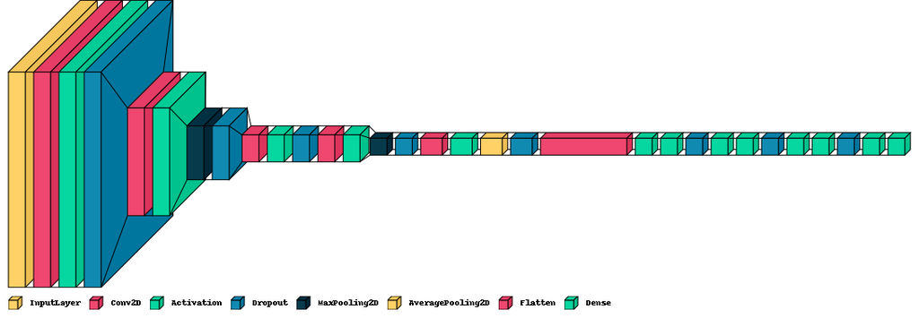

```python
visualkeras.layered_view(model5,legend=True)
# visualkeras.graph_view(model5)
# from PIL import ImageFont

# font = ImageFont.truetype("arial.ttf", 32)  # using comic sans is strictly prohibited!
# visualkeras.layered_view(model, legend=True, font=font)  # font is optional!
```

(when experimenting, run notebook at least up to here for base data and functions).

# **Part II: Experimentation**

### **Model CNN5**

We build a model CNN5. As compared to CNN0 it uses more convolution layers (increasing progressively in size), and more dense layers (i.e. increase in depth).

```python
model5.compile(loss='binary_crossentropy', optimizer='adam', metrics=['accuracy'])
callbacks = [EarlyStopping(monitor='val_loss', patience=2),
             ModelCheckpoint('.mdl_wts.hdf5', monitor='val_loss', save_best_only=True)]
```

```python
#Fit the model
history5=model5.fit(train_images,train_labels,batch_size=32,callbacks=callbacks,validation_split=0.2,epochs=20,verbose=1)
```

```python
# save the model
model5.save('/content/drive/MyDrive/Data/CNN5.h5')
```

```
None
```

```
 Test_Accuracy:- 0.9526923298835754
              precision    recall  f1-score   support

           0       0.93      0.98      0.95      1300
           1       0.98      0.93      0.95      1300

    accuracy                           0.95      2600
   macro avg       0.95      0.95      0.95      2600
weighted avg       0.95      0.95      0.95      2600
```

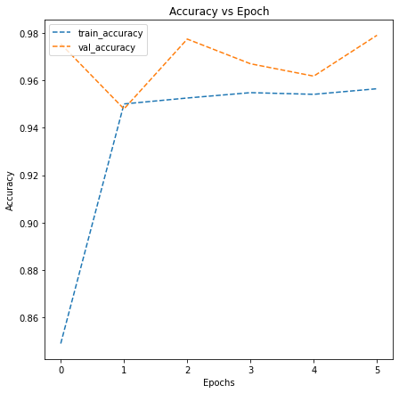

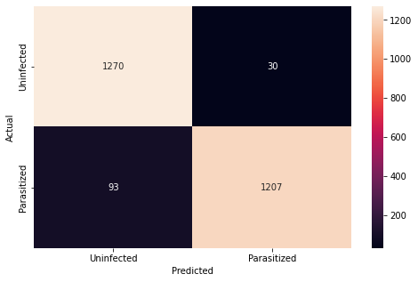

```python
display(plot_accuracy(history5))
accuracy = model5.evaluate(test_images, test_labels, verbose=1)
print('\n', 'Test_Accuracy:-', accuracy[1])
prediction_report(model5,test_images)
```

#### **Notes on CNN5:**

The CNN5 model uses a simple yet efficient architecture, and reaches around 95% accuracy like the other models.

### **Feature Engineering: HSV Images**

We convert RGB images to HSV, and train CNN5 on the new database.

```python
# Create HSV database of images (Q: does it modify original database?)
train_images_hsv=[]
for i in train_images:
  train_images_hsv.append(cv2.cvtColor(i,cv2.COLOR_BGR2HSV))
train_images_hsv=np.array(train_images_hsv)
test_images_hsv=[]
for i in test_images:
  test_images_hsv.append(cv2.cvtColor(i,cv2.COLOR_BGR2HSV))
test_images_hsv=np.array(test_images_hsv)
```

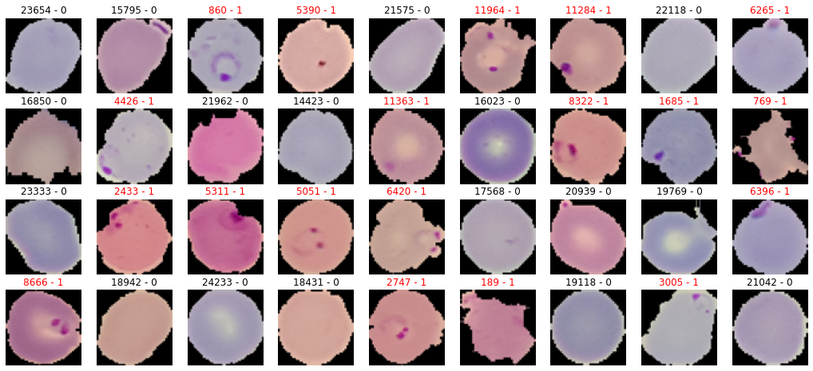

```python
plot_randomimages(train_images,train_labels,seed=42)
```

[output not shown]

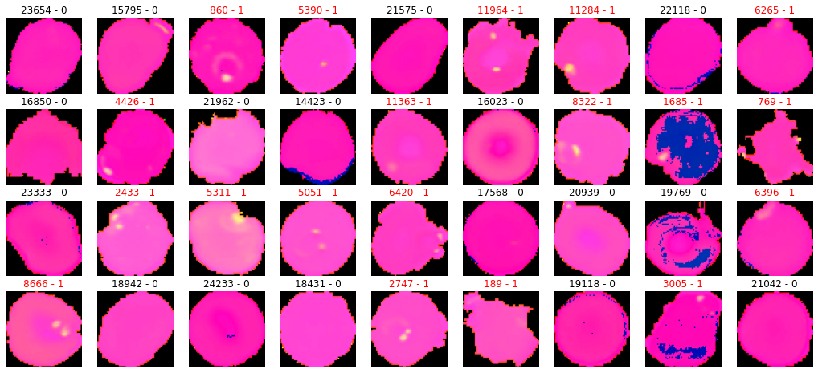

```python
plot_randomimages(train_images_hsv,train_labels,seed=42)
```

```python
model5.compile(loss='binary_crossentropy', optimizer='adam', metrics=['accuracy'])
callbacks = [EarlyStopping(monitor='val_loss', patience=2),
             ModelCheckpoint('.mdl_wts.hdf5', monitor='val_loss', save_best_only=True)]
```

```python
#Fit the model
history5=model5.fit(train_images_hsv,train_labels,batch_size=32,callbacks=callbacks,validation_split=0.2,epochs=20,verbose=1)
```

```
None
```

[output not shown]

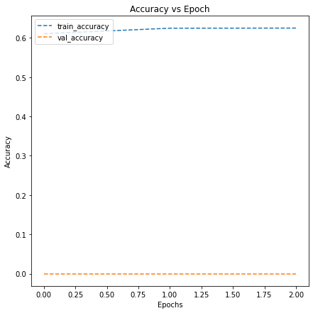

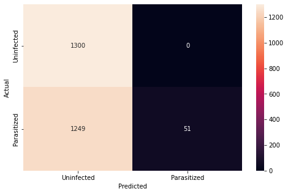

```python
display(plot_accuracy(history5))
accuracy = model5.evaluate(test_images_hsv, test_labels, verbose=1)
print('\n', 'Test_Accuracy:-', accuracy[1])
prediction_report(model5,test_images_hsv)
```

#### **Notes on HSV Images**

- This is not necessarily due to data loss during the transformation. In fact conversion from RGB to HSV can be reverted. It is, however, a nonlinear transformation (with modulo) and as such is nontrivial for feature engineering.
- The reason why the HSV dataset fails may be seen in the visualization above: some images show spurious blue marks which dont seem relevant.

### **Pretreatment of RGB Images**

```
[0. 0. 0.]
```

```
None
```

```
None
```

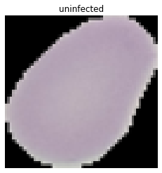

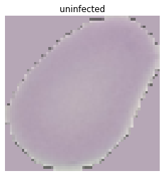

```python
index=1686
index=int(np.random.randint(0, train_images.shape[0], 1))
ref_image=train_images[index]
ref_label=train_labels[index]
print(ref_image[0,0,:])# borders are black
display(plot_oneimage(ref_image,ref_label))
#
def bordercolortomean(ref_image):# returns a copy of image where color replaced by image mean
  new_image=ref_image.copy()
  lower =(0, 0, 0) # lower bound for each channel
  upper = (100/255, 100/255, 100/255) # upper bound for each channel
  dxm=16# offsets to define center of image where mean is computed
  dym=16
  meancolor=[np.mean(ref_image[dxm:63-dxm,dym:63-dym,0]), np.mean(ref_image[dxm:63-dxm,dym:63-dym,1]), np.mean(ref_image[dxm:63-dxm,dym:63-dym,2])]# mean color
  mask = cv2.inRange(new_image, lower, upper)
  new_image[mask != 0] = meancolor
  return new_image

new_image=bordercolortomean(ref_image)
display(plot_oneimage(new_image,ref_label))
```

```python
# Create new database with pretreatment
# Create HSV database of images (Q: does it modify original database?)

train_images_noborders=[]
for i in train_images:
  train_images_noborders.append(bordercolortomean(i))
train_images_noborders=np.array(train_images_noborders)
test_images_noborders=[]
for i in test_images:
  colortomean(i,bordercolor)
  test_images_noborders.append(bordercolortomean(i))
test_images_noborders=np.array(test_images_noborders)
```

[output not shown]

```python
model5=buildCNN5()
# model5.summary()
model5.compile(loss='binary_crossentropy', optimizer='adam', metrics=['accuracy'])
callbacks = [EarlyStopping(monitor='val_loss', patience=2),
             ModelCheckpoint('.mdl_wts.hdf5', monitor='val_loss', save_best_only=True)]
#Fit the model
history5=model5.fit(train_images_noborders,train_labels,batch_size=32,callbacks=callbacks,validation_split=0.2,epochs=20,verbose=1)
```

```
None
```

```
 Test_Accuracy:- 0.9523077011108398
              precision    recall  f1-score   support

           0       0.95      0.96      0.95      1300
           1       0.96      0.95      0.95      1300

    accuracy                           0.95      2600
   macro avg       0.95      0.95      0.95      2600
weighted avg       0.95      0.95      0.95      2600
```

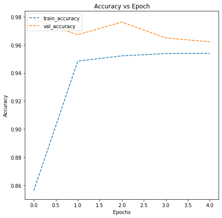

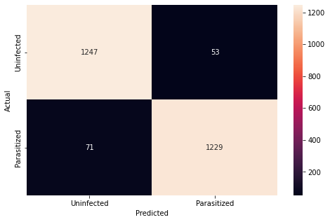

```python
display(plot_accuracy(history5))
accuracy = model5.evaluate(test_images_noborders, test_labels, verbose=1)
print('\n', 'Test_Accuracy:-', accuracy[1])
prediction_report(model5,test_images_noborders)
```

#### **Notes on Pretreatement of RGB Images**

We have tested a pretreatment of RGB images, consisting of changing the border color (black) to the one of the image mean color (in the center reason).

- The rationale behind this is that the border area of the red cells are irrelevant for the classification. In theory, all cells should exhibit a rather ellipsoidal border, but in practice the borders can take very complex shapes due to framing/cropping. With the present transformation we want to avoid feeding this irrelevant information to the CNN.
- The transformation doesnt improve the performances of CNN5 (it doesnt decrease them thought).

### **Data Augmentation Attempt 2**

We consider data augmentation with limited set of rotations +90,+180,+270 as well as horizontal flip.

```
None
```

```
None
```

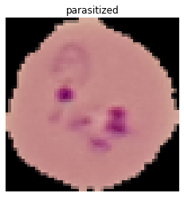

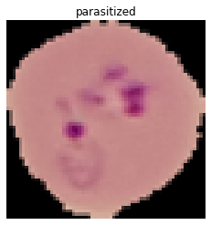

```python
# rotate/flip one image

index=1687
#index=int(np.random.randint(0, train_images.shape[0], 1))
ref_image=train_images[index]
ref_label=train_labels[index]
display(plot_oneimage(ref_image,ref_label))

new_image=ref_image.copy()
new_image = cv2.flip(new_image, 0)# flip (horizontally or vertically - same here)
# new_image = cv2.rotate(new_image, cv2.cv2.ROTATE_90_CLOCKWISE)
# new_image = cv2.rotate(new_image, cv2.cv2.ROTATE_180)
# new_image = cv2.rotate(new_image, cv2.cv2.ROTATE_90_COUNTERCLOCKWISE)
display(plot_oneimage(new_image,ref_label))
```

```
(-0.5, 63.5, 63.5, -0.5)
```

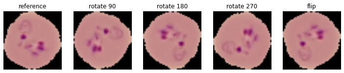

```python
# Repeat for all cases for illustration
index=1687
#index=int(np.random.randint(0, train_images.shape[0], 1))
ref_image=train_images[index]
ref_label=train_labels[index]
# display(plot_oneimage(ref_image,ref_label))

# new_image=ref_image.copy()
# new_image = cv2.flip(ref_image.copy(), 0)# flip (horizontally or vertically - same here)
# new_image = cv2.rotate(ref_image.copy(), cv2.cv2.ROTATE_90_CLOCKWISE)
# new_image = cv2.rotate(ref_image.copy(), cv2.cv2.ROTATE_180)
# new_image = cv2.rotate(ref_image.copy(), cv2.cv2.ROTATE_90_COUNTERCLOCKWISE)


nx=8
plt.figure(None , figsize = (20 , 4))
plt.subplot(1, nx, 1)
plt.imshow(ref_image)
plt.title('reference')
plt.axis('off')
plt.subplot(1, nx, 2)
plt.imshow(cv2.rotate(ref_image.copy(), cv2.cv2.ROTATE_90_CLOCKWISE))
plt.title('rotate 90')
plt.axis('off')
plt.subplot(1, nx, 3)
plt.imshow(cv2.rotate(ref_image.copy(), cv2.cv2.ROTATE_180))
plt.title('rotate 180')
plt.axis('off')
plt.subplot(1, nx, 4)
plt.imshow(cv2.rotate(ref_image.copy(), cv2.cv2.ROTATE_90_COUNTERCLOCKWISE))
plt.title('rotate 270')
plt.axis('off')
plt.subplot(1, nx, 5)
plt.imshow(cv2.flip(ref_image.copy(), 0))
plt.title('flip')
plt.axis('off')
```

```python
# create extended database with transformed images
# Here we can augment 1 image to 8 images using 4 rotation angles and flipped/unflipped state
# (note: using both flip horizontal and vertical is redundant when combined with rotations)
train_images_extended=[]
train_labels_extended=[]
for i,j in zip(train_images,train_labels):
  #
  a1=i.copy()# original
  a2= cv2.rotate(i.copy(), cv2.cv2.ROTATE_90_CLOCKWISE)
  a3= cv2.rotate(i.copy(), cv2.cv2.ROTATE_180)
  a4= cv2.rotate(i.copy(), cv2.cv2.ROTATE_90_COUNTERCLOCKWISE)
  #
  a1f=i.copy()#
  a2f= cv2.rotate(i.copy(), cv2.cv2.ROTATE_90_CLOCKWISE)
  a3f= cv2.rotate(i.copy(), cv2.cv2.ROTATE_180)
  a4f= cv2.rotate(i.copy(), cv2.cv2.ROTATE_90_COUNTERCLOCKWISE)
  a1f=cv2.flip(a1f,0)
  a2f=cv2.flip(a2f,0)
  a3f=cv2.flip(a3f,0)
  a4f=cv2.flip(a4f,0)
  #
  train_images_extended.append(a1)
  train_images_extended.append(a2)
  train_images_extended.append(a3)
  train_images_extended.append(a4)
  train_images_extended.append(a1f)
  train_images_extended.append(a2f)
  train_images_extended.append(a3f)
  train_images_extended.append(a4f)
  for k in range(8):
    train_labels_extended.append(j)

train_images_extended=np.array(train_images_extended)
train_labels_extended=np.array(train_labels_extended)
```

```python
train_labels_extended.shape
```

```
(199664, 2)
```

```python
model5=buildCNN5()
# model5.summary()
model5.compile(loss='binary_crossentropy', optimizer='adam', metrics=['accuracy'])
callbacks = [EarlyStopping(monitor='val_loss', patience=2),
             ModelCheckpoint('.mdl_wts.hdf5', monitor='val_loss', save_best_only=True)]
```

```python
#Fit the model
history5=model5.fit(train_images_extended,train_labels_extended,batch_size=32,callbacks=callbacks,validation_split=0.2,epochs=20,verbose=1)
```

```python
# save the model
model5.save('/content/drive/MyDrive/Data/CNN5_dataextended.h5')
```

```
None
```

```
 Test_Accuracy:- 0.9569230675697327
              precision    recall  f1-score   support

           0       0.95      0.96      0.96      1300
           1       0.96      0.95      0.96      1300

    accuracy                           0.96      2600
   macro avg       0.96      0.96      0.96      2600
weighted avg       0.96      0.96      0.96      2600
```

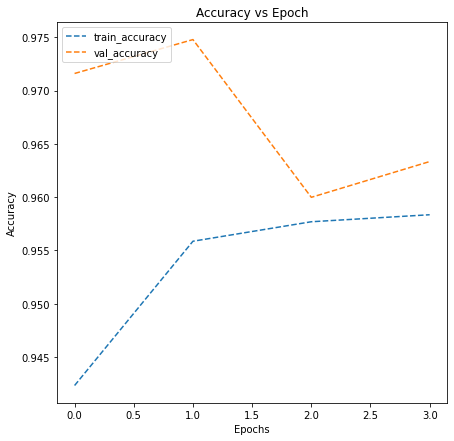

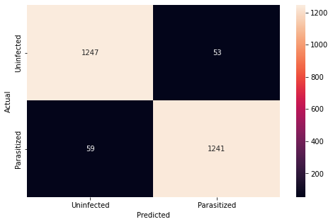

```python
display(plot_accuracy(history5))
accuracy = model5.evaluate(test_images, test_labels, verbose=1)
print('\n', 'Test_Accuracy:-', accuracy[1])
prediction_report(model5,test_images)
```

#### **Notes on Data Augmentation Attempt 2**

The Data Augmentation here consists of rotating each image to +90,180, or 270 degrees as well as flipping horizontally, resulting in 8 images from a single one.

- These are all "natural transformations", i.e. transformations that could occur randomly when framing the red cells with the experimental protocol.
- This sligthly increases the model performance, to an accuracy of 96%.

### **Pretreatment of RGB Images Attempt 2**

We consider again pretreatment of the RGB images. This time, we want to uniformize the mean color of any image and make the background color match it.

```python
def replacebordercolor(image,newcolor):# replace border color with given color (in same image)
  lower =(0, 0, 0) # lower bound for each channel
  upper = (10/255, 10/255, 10/255) # upper bound for each channel
  mask = cv2.inRange(image, lower, upper)
  image[mask != 0] = newcolor
```

```
(118, 136, 3)
0 221 0 175 0 179
[184.17716499 133.12533432 149.42368348]
[10.54593281 13.98854181  8.19547902]
```

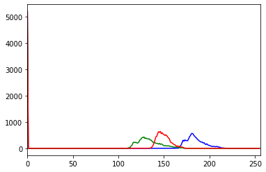

```
None
```

```
--------------------------------------------------
[20. 20. 20.]
[10.54593281 13.98854181  8.19547902]
```

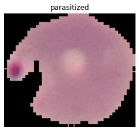

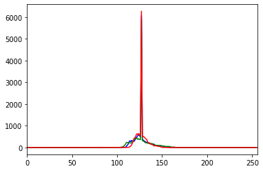

```
None
```

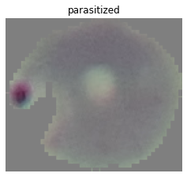

```python
# consider one big image

# index=1687
index=int(np.random.randint(0, train_bigimages.shape[0], 1))
img=train_bigimages[index].copy()
ref_label=train_labels[index]

# print min-max of all colors
print(img.shape)# shape may vary!
print(np.min(img[:,:,0]),np.max(img[:,:,0]),np.min(img[:,:,1]),np.max(img[:,:,1]),np.min(img[:,:,2]),np.max(img[:,:,2]))

# determine mean color (omitting black from borders)
img2=img.copy()
img2=np.where(img2!=0,img2,np.nan)
#
mean_color=np.nanmean(img2,axis=(0,1))
std_color=np.nanstd(img2,axis=(0,1))
print(mean_color)
print(std_color)
# determine std of color

plot_colorhist(img)
# Display image
display(plot_oneimage(img,ref_label))

print('-'*50)
#consider some built-in transformations
# img=cv2.cvtColor(img,cv2.COLOR_BGR2HSV)# hsv
# img=cv2.cvtColor(img,cv2.COLOR_BGR2GRAY)# grayscale
# img = cv2.normalize(img,  np.zeros((224,224)), 0, 255, cv2.NORM_MINMAX)# normalize

#Custom transformation: borders to mean color
replacebordercolor(img,mean_color)

# Custom transformation: normalize to arbitrary mean and std
if True:
  ref_mean=np.array([127.,127.,127.])
  ref_std=np.array([20.,20.,20.])


  print(ref_std)
  print(std_color)
  # img[:,:,0] = (img[:,:,0]- mean_color[0])*ref_std[0]/std_color[0] + ref_mean[0]
  # img[:,:,1] = (img[:,:,1]- mean_color[1])*ref_std[1]/std_color[1] + ref_mean[1]
  # img[:,:,2] = (img[:,:,2]- mean_color[2])*ref_std[2]/std_color[2] + ref_mean[2]

  img[:,:,0] = img[:,:,0]- mean_color[0]
  img[:,:,1] = img[:,:,1]- mean_color[1]
  img[:,:,2] = img[:,:,2]- mean_color[2]

  img[:,:,0] = img[:,:,0] + ref_mean[0]
  img[:,:,1] = img[:,:,1] + ref_mean[1]
  img[:,:,2] = img[:,:,2] + ref_mean[2]

  #
  # bounds
  img[img>255]=255
  img[img<0]=0

plot_colorhist(img)

# Display resulting image
display(plot_oneimage(img,ref_label))
```

```python
# Recreate image database with transformations

def transform_bigimage(image):
  # determine mean color (omitting black from borders)
  img=image.copy()
  img=np.where(img!=0,img,np.nan)
  mean_color=np.nanmean(img,axis=(0,1))
  img=image.copy()

  replacebordercolor(img,mean_color)# replace border with mean color
  ref_mean=np.array([127.,127.,127.])# reference mean
  img[:,:,0] = img[:,:,0]- mean_color[0]  + ref_mean[0]
  img[:,:,1] = img[:,:,1]- mean_color[1] + ref_mean[1]
  img[:,:,2] = img[:,:,2]- mean_color[2] + ref_mean[2]
  #
  # bounds
  img[img>255]=255
  img[img<0]=0
  return img
```

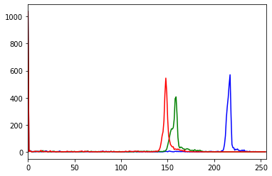

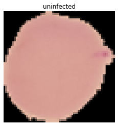

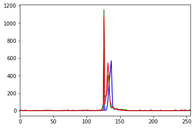

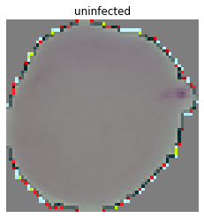

```python
# test one image
index=int(np.random.randint(0, train_images.shape[0], 1))
img=train_images[index].copy()
ref_label=train_labels[index]
plot_colorhist(img)
plot_oneimage(img,ref_label)

new_image=transform_bigimage(img)

plot_colorhist(new_image)
plot_oneimage(new_image,ref_label)
```

#### **Notes on RGB Images Pretreatment Attempt 2**

We have considered again pretreatment of the RGB images. We wanted to uniformize the mean color of any image and make the background color match it.

### **Data Augmentation Attempt 3**

We consider data augmentation with horizontal or vertical shifts of the images that loop on themselves.

```
None
```

```
(64, 64, 3)
(64, 64, 3)
```

```
None
```

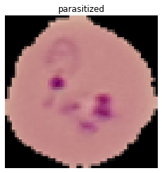

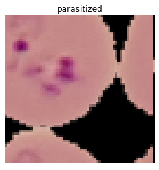

```python
# transform one image

index=1687
#index=int(np.random.randint(0, train_images.shape[0], 1))
ref_image=train_images[index]
ref_label=train_labels[index]
display(plot_oneimage(ref_image,ref_label))

new_image=ref_image.copy()
# new_image = cv2.flip(new_image, 0)# flip (horizontally or vertically - same here)
# new_image = cv2.rotate(new_image, cv2.cv2.ROTATE_90_CLOCKWISE)
# new_image = cv2.rotate(new_image, cv2.cv2.ROTATE_180)
# new_image = cv2.rotate(new_image, cv2.cv2.ROTATE_90_COUNTERCLOCKWISE)

# new_image=translate_perio(new_image,16,16)
# new_image=translate_perio(new_image,32,32)
new_image=translate_perio(new_image,48,48)
print(ref_image.shape)
print(new_image.shape)


display(plot_oneimage(new_image,ref_label))
```

```
(-0.5, 63.5, 63.5, -0.5)
```

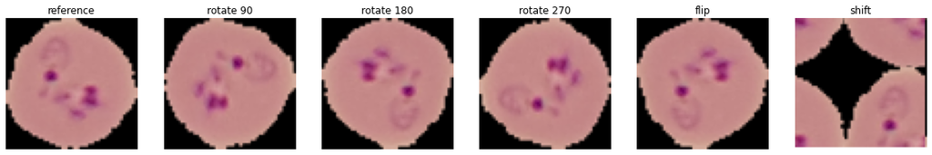

```python
# Repeat for all cases for illustration
index=1687
#index=int(np.random.randint(0, train_images.shape[0], 1))
ref_image=train_images[index]
ref_label=train_labels[index]
# display(plot_oneimage(ref_image,ref_label))

# new_image=ref_image.copy()
# new_image = cv2.flip(ref_image.copy(), 0)# flip (horizontally or vertically - same here)
# new_image = cv2.rotate(ref_image.copy(), cv2.cv2.ROTATE_90_CLOCKWISE)
# new_image = cv2.rotate(ref_image.copy(), cv2.cv2.ROTATE_180)
# new_image = cv2.rotate(ref_image.copy(), cv2.cv2.ROTATE_90_COUNTERCLOCKWISE)


nx=6
plt.figure(None , figsize = (20 , 4))
plt.subplot(1, nx, 1)
plt.imshow(ref_image)
plt.title('reference')
plt.axis('off')
plt.subplot(1, nx, 2)
plt.imshow(cv2.rotate(ref_image.copy(), cv2.cv2.ROTATE_90_CLOCKWISE))
plt.title('rotate 90')
plt.axis('off')
plt.subplot(1, nx, 3)
plt.imshow(cv2.rotate(ref_image.copy(), cv2.cv2.ROTATE_180))
plt.title('rotate 180')
plt.axis('off')
plt.subplot(1, nx, 4)
plt.imshow(cv2.rotate(ref_image.copy(), cv2.cv2.ROTATE_90_COUNTERCLOCKWISE))
plt.title('rotate 270')
plt.axis('off')
plt.subplot(1, nx, 5)
plt.imshow(cv2.flip(ref_image.copy(), 0))
plt.title('flip')
plt.axis('off')
plt.subplot(1, nx, 6)
plt.imshow(translate_perio(ref_image.copy(),24,24))
plt.title('shift')
plt.axis('off')
```

```python
# Create a database with random shifts

# create extended database with transformed images
# Here we can augment 1 image to 8 images using 4 rotation angles and flipped/unflipped state
# (note: using both flip horizontal and vertical is redundant when combined with rotations)
train_images_extended2=[]
train_labels_extended2=[]
for i,j in zip(train_images,train_labels):
  #
  a1=i.copy()# original
  a2=translate_perio(i.copy(),16,0)
  a3=translate_perio(i.copy(),0,16)
  a4=translate_perio(i.copy(),16,16)
  #
  a1f=translate_perio(i.copy(),32,0)
  a2f=translate_perio(i.copy(),0,32)
  a3f=translate_perio(i.copy(),32,32)
  #
  a1e=translate_perio(i.copy(),48,0)
  a2e=translate_perio(i.copy(),0,48)
  a3e=translate_perio(i.copy(),48,48)
  #
  train_images_extended2.append(a1)
  train_images_extended2.append(a2)
  train_images_extended2.append(a3)
  train_images_extended2.append(a4)
  train_images_extended2.append(a1f)
  train_images_extended2.append(a2f)
  train_images_extended2.append(a3f)
  train_images_extended2.append(a1e)
  train_images_extended2.append(a2e)
  train_images_extended2.append(a3e)
  for k in range(10):
    train_labels_extended2.append(j)

train_images_extended2=np.array(train_images_extended2)
train_labels_extended2=np.array(train_labels_extended2)
```

```python
model5=buildCNN5()
# model5.summary()
model5.compile(loss='binary_crossentropy', optimizer='adam', metrics=['accuracy'])
callbacks = [EarlyStopping(monitor='val_loss', patience=2),
             ModelCheckpoint('.mdl_wts.hdf5', monitor='val_loss', save_best_only=True)]
```

```python
#Fit the model
history5=model5.fit(train_images_extended2,train_labels_extended2,batch_size=32,callbacks=callbacks,validation_split=0.2,epochs=20,verbose=1)
```

```python
# save the model
model5.save('/content/drive/MyDrive/Data/CNN5_dataextended2.h5')
```

```
None
```

```
 Test_Accuracy:- 0.9546154141426086
              precision    recall  f1-score   support

           0       0.95      0.96      0.96      1300
           1       0.96      0.94      0.95      1300

    accuracy                           0.95      2600
   macro avg       0.95      0.95      0.95      2600
weighted avg       0.95      0.95      0.95      2600
```

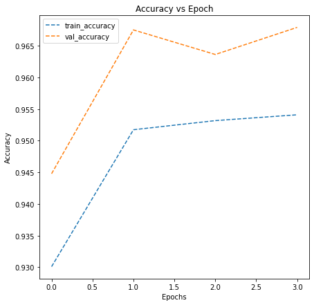

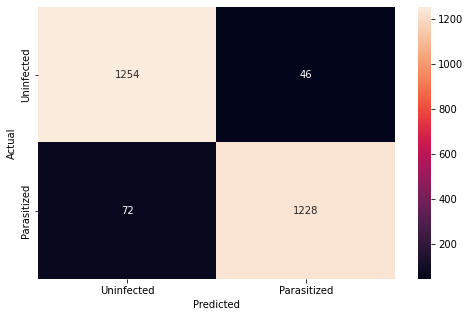

```python
display(plot_accuracy(history5))
accuracy = model5.evaluate(test_images, test_labels, verbose=1)
print('\n', 'Test_Accuracy:-', accuracy[1])
prediction_report(model5,test_images)
```

```python
# Lets analyze the database of misclassified
from tensorflow.keras.models import load_model
model = load_model('/content/drive/MyDrive/Data/CNN5_dataextended2.h5')

y_pred_proba = model.predict(test_images)# predicted probability (two classes)
y_pred = np.argmax(y_pred_proba,axis = -1)# convert boolean
y_true = np.argmax(test_labels,axis = -1)

# Build database of misclassified images
misclass_images=[]
misclass_labels=[]
misclass_probas=[]# predicted probability 0-1
misclass_index=[]# save index from full database
for count,(i,j,k,l) in enumerate(zip(test_images,y_pred,y_true,y_pred_proba)):
  if j != k:
    misclass_images.append(i)# image
    misclass_labels.append(k)# truth
    misclass_probas.append(l[0])# predicted probability
    misclass_index.append(count)# save index from database

# Sort by increasing probability (one liner!)
misclass_probas,misclass_labels,misclass_images = map(list, zip(*sorted(zip(misclass_probas,misclass_labels,misclass_images), reverse=True)))
```

```
118
```

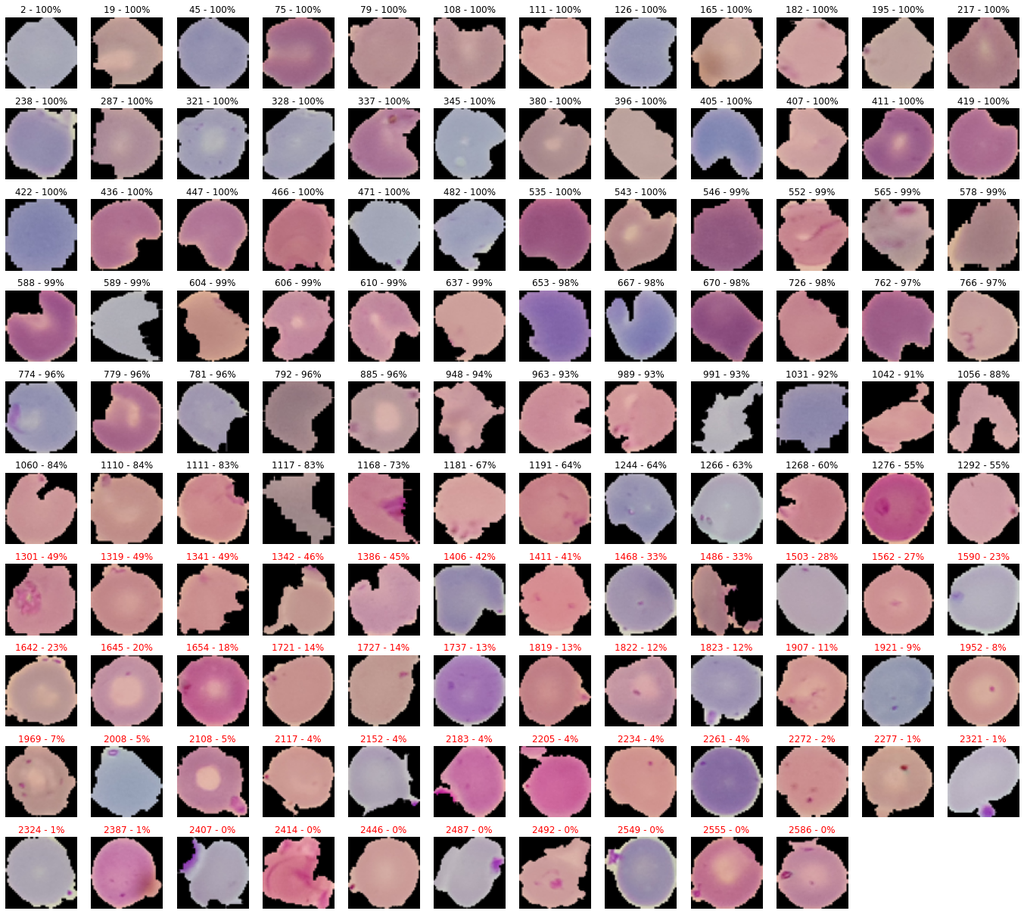

```python
# Visualize all the misclassified from CNN0:
print(len(misclass_probas))# there are 129 misclassified images
np.random.seed()
plt.figure(1 , figsize = (24 , 24))

niter=min(len(misclass_probas),11*12)
for n in range(niter):
    plt.subplot(11, 12, n+1)
    index=n# just follow
    # index = int(np.random.randint(0, len(misclass_probas), 1))# any
    # index = int(np.random.randint(0, len(misclass_probas)/4, 1))# first quartile
    # index = int(np.random.randint(3*len(misclass_probas)/4, len(misclass_probas), 1))# last quartile
    plt.imshow(misclass_images[index])
    if misclass_labels[index] == 1:# uninfected
      plt.title(str(misclass_index[index])+' - '+str(round(misclass_probas[index]*100))+'%')
    else:
      plt.title(str(misclass_index[index])+' - '+str(round(misclass_probas[index]*100))+'%',color='r')

    plt.axis('off')
```

#### **Notes on Data Augmentation Attempt 3**

We have augmented the data with shifts of the red cell images. Accuracy is similar overall, we still misclassified roughly the same 120 cases.

- The rationale behind introduced the shifts is that detecing the malaria consists in detecting small parasites. The overall structure of the image, notably the complex structure of the red cell envelope, is irrelevant (i.e. should not be learned).

### **Data Augmentation Attempt 4**

We consider data augmentation with limited set of rotations +90,+180,+270 as well as horizontal flip, and translational shifts (that loop on themselves). This is basically a combination of the techniques from Attempt 2 and 3. This results in a very large database of images.

```python
# create extended database with transformed images
# Here we can augment 1 image to 8 images using 4 rotation angles and flipped/unflipped state
# (note: using both flip horizontal and vertical is redundant when combined with rotations)
train_images_extended=[]
train_labels_extended=[]
cc=0
for i,j in zip(train_images,train_labels):
  print(cc)
  cc+=1
  #
  # We obtain 8 images from flip and rotations
  alist=[]
  alist.append(i.copy())# original
  alist.append(cv2.rotate(i.copy(), cv2.cv2.ROTATE_90_CLOCKWISE))
  alist.append(cv2.rotate(i.copy(), cv2.cv2.ROTATE_180))
  alist.append(cv2.rotate(i.copy(), cv2.cv2.ROTATE_90_COUNTERCLOCKWISE))
  alist.append(cv2.flip(i.copy(),0))
  alist.append(cv2.flip(cv2.rotate(i.copy(), cv2.cv2.ROTATE_90_CLOCKWISE),0))
  alist.append(cv2.flip(cv2.rotate(i.copy(), cv2.cv2.ROTATE_180),0))
  alist.append(cv2.flip(cv2.rotate(i.copy(), cv2.cv2.ROTATE_90_COUNTERCLOCKWISE),0))
  #
  # Make 9 version for each one, resulting in 8x10 images
  for j in alist:
    for k in range(7):#10
      if k==0:
        a1=j.copy()# original
      elif k==1:
        a1=translate_perio(j.copy(),16,0)
      elif k==2:
        a1=translate_perio(j.copy(),0,16)
      elif k==3:
        a1=translate_perio(j.copy(),16,16)
      elif k==4:
        a1=translate_perio(j.copy(),32,0)
      elif k==5:
        a1=translate_perio(j.copy(),0,32)
      elif k==6:
        a1=translate_perio(j.copy(),32,32)
      # elif k==7:
      #   a1=translate_perio(j.copy(),48,0)
      # elif k==8:
      #   a1=translate_perio(j.copy(),0,48)
      # else:
      #   a1=translate_perio(j.copy(),48,48)
      #
      train_images_extended.append(a1)
      train_labels_extended.append(j)
```

[output not shown]

[output cut: 4946 more lines]

[output not shown]

```python
for i in train_images_extended:
    i=np.array(i)
for i in train_labels_extended:
    i=np.array(i)
```

```python
model5=buildCNN5()
# model5.summary()
model5.compile(loss='binary_crossentropy', optimizer='adam', metrics=['accuracy'])
callbacks = [EarlyStopping(monitor='val_loss', patience=2),
             ModelCheckpoint('.mdl_wts.hdf5', monitor='val_loss', save_best_only=True)]
```

```python
#Fit the model
history5=model5.fit(train_images_extended,train_labels_extended,batch_size=32,callbacks=callbacks,validation_split=0.2,epochs=20,verbose=1)
```

[output not shown]

[output cut: 78 more lines]

[output not shown]

```python
# save the model
model5.save('/content/drive/MyDrive/Data/CNN5_dataextended4.h5')
```

```python
display(plot_accuracy(history5))
accuracy = model5.evaluate(test_images, test_labels, verbose=1)
print('\n', 'Test_Accuracy:-', accuracy[1])
prediction_report(model5,test_images)
```

#### **Notes on Data Augmentation Attempt 4**

We have augmented the data with rotation, flip and shifts of the red cell images.

- The bottleneck is here RAM as we cannot store all images (8x10 times the original database). Google Collab always crashes at execution (even with a limited pool of images 8x7 the original database).
- For the above reasons, we abandon this method as well. It may however be useful for the final model.